# R for Big Data — recent topics

Wilson Cai, Department of Biostatistics, UC Berkeley

wcai@berkeley.edu

2016-02-04

## I. Parallelization

### i. Useful terminology

- Cores: We’ll use this term to mean the different processing units available on a single node.
- Nodes: We’ll use this term to mean the different computers, each with their own distinct memory, that make up a cluster or supercomputer.
- Processes: computational tasks executing on a machine; multiple processes may be executing at once. A given program may start up multiple processes at once. Ideally we have no more processes than cores on a node.
- Threads: multiple paths of execution within a single process; the OS sees the threads as a single process, but one can think of them as ‘lightweight’ processes. Ideally when considering the processes and their threads, we would have no more processes and threads combined than cores on a node.
- Forking: child processes are spawned that are identical to the parent, but with different process IDs and their own memory.
- sockets: some of R’s parallel functionality involves creating new R processes (e.g., starting processes via *Rscript*) and communicating with them via a communication technology called sockets.

### ii. shared memory v.s. distributed memory

For shared memory parallelism, each core is accessing the same memory so there is no need to pass information (in the form of messages) between different machines. But in some programming contexts one needs to be careful that activity on different cores doesn’t mistakenly overwrite places in memory that are used by other cores.

Parallel programming for distributed memory parallelism requires passing messages between the different nodes. The standard protocol for doing this is MPI, of which there are various versions, including *openMPI*.

The R package *Rmpi* implements MPI in R. The *pbd* packages for R also implement MPI as well as distributed linear algebra (linear algebra calculations across nodes).

Python has a package *mpi4py* that allows use of MPI within Python.

Matlab has its own system for distributed computation, called the Distributed Computing Server (DCS), requiring additional licensing above the standard Matlab installation.

This tutorial will not cover distributed memory parallelization, though a future tutorial may.

### iii. other types of parallel processing

#### 1. GPU

GPUs (Graphics Processing Units) are processing units originally designed for rendering graphics on a computer quickly. This is done by having a large number of simple processing units for massively parallel calculation. The idea of general purpose GPU (GPGPU) computing is to exploit this capability for general computation.

For more information, refer to [the workshop on using GPUs](http://statistics.berkeley.edu/computing/gpu) by Chris Paciorek (Department of Statistics) in Spring 2014.

#### 2. Spark and Hadoop

Spark and Hadoop are systems for implementing computations in a distributed memory environment, using the MapReduce approach. For more information, refer to [the workshop on using Spark](http://statistics.berkeley.edu/computing/gpu) by Chris Paciorek (Department of Statistics) in Fall 2014.

## II. Basic paralleized loops/ apply in R

All of the functionality discussed here applies **ONLY** if the iterations/loops of your calculations can be done completely separately and do not depend on one another . This scenario is called an *embarrassingly parallel* computation. So coding up the evolution of a time series or a Markov chain is not possible using these tools. However, bootstrapping, random forests, simulation studies, cross-validation and many other statistical methods can be handled in this way.

### i. Parallel for loops with foreach

A simple way to exploit parallelism in R is to use the *foreach* package to do a for loop in parallel.

The *foreach* package provides a *foreach* command that allows you to do this easily. *foreach* can use a variety of parallel ``back-ends’’. For our purposes, the main one is use of the *parallel* package to use shared memory cores. When using *parallel* as the back-end, you should see multiple processes (as many as you registered; ideally each at 100%) when you monitor CPU usage. The multiple processes are created by forking or using sockets. *foreach* can also use *Rmpi* to access cores in a distributed memory setting, but that is beyond the scope of this document.

```r
library(parallel) # one of the core R packages
library(doParallel)
# library(multicore); library(doMC) # alternative to parallel/doParallel
# library(Rmpi); library(doMPI) # to use Rmpi as the back-end
library(foreach)
library(iterators)

taskFun <- function(){
    mn <- mean(rnorm(10000000))
    return(mn)
}
nCores <- 4  # to set manually
registerDoParallel(nCores)
# registerDoMC(nCores) # alternative to registerDoParallel
# cl <- startMPIcluster(nCores); registerDoMPI(cl) # when using Rmpi as the back-end


# for(i in 1:30){
  # outSub <- taskFun()
# }

out <- foreach(i = 1:30, .combine = c) %dopar% {
    cat('Starting ', i, 'th job.\n', sep = '')
    outSub <- taskFun()
    cat('Finishing ', i, 'th job.\n', sep = '')
    outSub # this will become part of the out object
}
print(out)
```

```
##  [1] -2.602479e-04 -2.400061e-05 -2.588731e-04  7.564802e-05  1.495046e-04
##  [6]  1.591236e-04 -2.254327e-04 -1.436116e-05  2.867558e-04 -5.803741e-04
## [11]  2.310138e-04 -2.716373e-05 -1.064013e-04 -9.959290e-05  1.129361e-04
## [16] -3.977665e-04 -6.572994e-05 -3.160563e-04 -9.620622e-05  2.549314e-04
## [21]  4.214098e-04 -5.644878e-04 -4.542944e-04  5.985127e-05  2.093951e-04
## [26]  1.968070e-05  2.144350e-05 -5.072304e-04 -3.954282e-04 -5.742503e-05
```

(Note that the printed statements from `cat` are not showing up in the creation of this document but should show if you run the code.)

Note that *foreach* also provides functionality for collecting and managing the results to avoid some of the bookkeeping you would need to do if writing your own standard for loop. The result of *foreach* will generally be a list, unless we request the results be combined in different way, as we do here using `.combine = c`.

You can debug by running serially using *%do%* rather than *%dopar%*. Note that you may need to load packages within the *foreach* construct to ensure a package is available to all of the calculations.

### ii. Parallel apply with parallel

The *parallel* package has the ability to parallelize the various *apply* functions (apply, lapply, sapply, etc.). It’s a bit hard to find the [vignette for the parallel package](http://stat.ethz.ch/R-manual/R-devel/library/parallel/doc/parallel.pdf) because parallel is not listed as one of the contributed packages on CRAN (it gets installed with R by default).

We’ll consider parallel lapply and sapply. These rely on having started a cluster using *cluster*, which uses the PSOCK mechanism as in the SNOW package - starting new jobs via *Rscript* and communicating via a technology called sockets.

```r
library(parallel)
nCores <- 4  # to set manually
cl <- makeCluster(nCores)

nSims <- 60
input <- seq_len(nSims) # same as 1:nSims but more robust
taskFun <- function(i){
    mn <- mean(rnorm(1000000))
    return(mn)
}
# clusterExport(cl, c('x', 'y')) # if the processes need objects (x and y, here) from the master's workspace
system.time(
    res <- parSapply(cl, input, taskFun)
)
```

```
##    user  system elapsed
##   0.003   0.000   3.683
```

```r
system.time(
    res2 <- sapply(input, taskFun)
)
```

```
##    user  system elapsed
##   6.528   0.163   9.497
```

```r
res <- parLapply(cl, input, taskFun)

library(rbenchmark)
benchmark({res <- parSapply(cl, input, taskFun)}, {res2 <- sapply(input, taskFun)}, replications = 5)
```

```
##                                             test replications elapsed
## 1 {\n    res <- parSapply(cl, input, taskFun)\n}            5  13.700
## 2       {\n    res2 <- sapply(input, taskFun)\n}            5  31.115
##   relative user.self sys.self user.child sys.child
## 1    1.000     0.008    0.001          0         0
## 2    2.271    30.300    0.553          0         0
```

Here the miniscule user time is probably because the time spent in the worker processes is not counted at the level of the overall master process that dispatches the workers.

For help with these functions and additional related parallelization functions (including *parApply*), see `help(clusterApply)`.

*mclapply* is an alternative that uses forking to start up the worker processes.

```r
system.time(
    res <- mclapply(input, taskFun, mc.cores = nCores)
)
```

```
##    user  system elapsed
##  15.298   0.593   2.492
```

Note that some R packages can directly interact with the parallelization packages to work with multiple cores. E.g., the *boot* package can make use of the *parallel* package directly.

## III. *data.table*

In many cases, particularly on a machine with a lot of memory, R might be able to read the dataset into memory but computations with the dataset may be slow. The *data.table* package provides a lot of functionality for fast manipulation: indexing, merges/joins, assignment, grouping, etc. Let’s read in the airline dataset, specifying the column classes so that *fread()* doesn’t have to detect what they are. I’ll also use factors since factors are represented numerically. It only takes about 5 minutes to read the data in. We’ll see in the next section that this is much faster than with other approaches within R.

Airline data (https://www.ocf.berkeley.edu/~wcai/share/airlines/AirlineDataAll.csv)

- 123534969 observations
- 29 covariates

```r
require(data.table)
fileName <- './airlines/AirlineDataAll.csv'

system.time(
  dt <- read.csv(fileName, colClasses=c(rep("numeric", 8), "factor",
                            "numeric", "factor", rep("numeric", 5),
                            rep("factor", 2), rep("numeric", 4),
                            "factor", rep("numeric", 6)))
)

system.time(
dt <- fread(fileName, colClasses=c(rep("numeric", 8), "factor",
                            "numeric", "factor", rep("numeric", 5),
                            rep("factor", 2), rep("numeric", 4),
                            "factor", rep("numeric", 6)))
)
#Read 123534969 rows and 29 (of 29) columns from
#    11.203 GB file in 00:05:16

dt

class(dt)
# [1] "data.table" "data.frame"
```

Now let’s do some basic subsetting. We’ll see that setting a key and using binary search can improve lookup speed dramatically.

```r
system.time(sfo <- subset(dt, Origin == "SFO"))
## 8.8 seconds
system.time(sfoShort <- subset(dt, Origin == "SFO" & Distance < 1000))
## 12.7 seconds

system.time(setkey(dt, Origin, Distance))
## 33 seconds:
## takes some time, but will speed up later operations
tables()
##     NAME            NROW    MB
##[1,] dt       123,534,969 27334
##[2,] sfo        2,733,910   606
##[3,] sfoShort   1,707,171   379
##     COLS
##[1,] Year,Month,DayofMonth,DayOfWeek,DepTime,CRSDepTime,ArrTime,CRSArrTime,UniqueCarr
##[2,] Year,Month,DayofMonth,DayOfWeek,DepTime,CRSDepTime,ArrTime,CRSArrTime,UniqueCarr
##[3,] Year,Month,DayofMonth,DayOfWeek,DepTime,CRSDepTime,ArrTime,CRSArrTime,UniqueCarr
##     KEY
##[1,] Origin,Distance
##[2,]
##[3,]
##Total: 28,319MB

## vector scan
system.time(sfo <- subset(dt, Origin == "SFO"))
## 8.5 seconds
system.time(sfoShort <- subset(dt, Origin == "SFO" & Distance < 1000 ))
## 12.4 seconds

## binary search
system.time(sfo <- dt[.('SFO'), ])
## 0.8 seconds
```

Setting a key in *data.table* simply amounts to sorting based on the columns provided, which allows for fast lookup later using binary search algorithms, as seen with the last query. Think about the analogy of looking up by name vs. index. From my fairly quick look through the *data.table* documentation I don’t see a way to do the subsetting with distance less than 1000 using the specialized functionality of *data.table*.

There’s a bunch more to *data.table* and you’ll have to learn a modest amount of new syntax, but if you’re working with large datasets in memory, it will probably be well worth your while. Plus *data.table* objects are data frames (i.e., they inherit from data frames) so they are compatible with R code that uses dataframes.

### A note on hashing

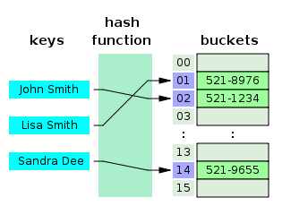

A hash function is a function that takes as input some data and maps it to a fixed-length output that can be used as a shortened reference to the data. We’ve seen this in the context of git commits where each commit was labeled with a long base-16 number. This also comes up when verifying files on the Internet. You can compute the hash value on the file you get and check that it is the same as the hash value associated with the legitimate copy of the file.

For our purposes here, hashing can allow one to look up values by their name via a hash table. The idea is that you have a set of key-value pairs (sometimes called a dictionary) where the key is the name associated with the value and the value is some arbitrary object. Hashing allows one to quickly determine an index associated with the key and therefore quickly find the relevant value based on the index. For example, one approach is to compute the hash as a function of the key and then take the remainder when dividing by the number of key-value pairs to get the index. Here’s the procedure in pseudocode:

```r
hash = hashfunc(key)
index = hash %% array_size # %% is modulo operator - it gives the remainder
```

In general, there will be collisions, with multiple keys assigned to the same index, but usually there will be a small number of keys associated with a given index or slot, and determining the correct value within a given index/slot (also called a bucket) is fast. Put another way, the hash function distributes the keys amongst an array of buckets and allows one to look up the appropriate bucket quickly based on the computed index value. When the hash table is properly set up, the cost of looking up a value does not depend on the number of key-value pairs stored.

## IV. *dplyr*

The *dplyr* package is the successor to the *plyr* package, providing *plyr* type functionality for data frames with enhancements for working with large tables and accessing databases (among other things). With *dplyr* one can work with data stored in the *data.table* format and in external databases.

```r
library(dplyr)
# with database
cis <- src_sqlite("/tmp/cis.db")
authors <- tbl(cis, "authors")
authors

# with data.table
fileName <- './airlines/AirlineDataAll.csv'
flights <- tbl_dt(fread(fileName, colClasses=c(rep("numeric", 8), "factor",
                            "numeric", "factor", rep("numeric", 5),
                            rep("factor", 2), rep("numeric", 4),
                            "factor", rep("numeric", 6))))

# now use dplyr functionality on 'authors' or 'flights'
# example analysis
summarize(group_by(flights, UniqueCarrier), mean(DepDelay, na.rm=TRUE))
group_by(flights, UniqueCarrier) %>% summarize(mean(DepDelay, na.rm=TRUE))
# Source: local data table [29 x 2]
#
#   UniqueCarrier mean(DepDelay, na.rm = TRUE)
#1             PS                     8.928104
#2             TW                     7.658251
#3             UA                     9.667930
#4             WN                     9.077167
#5             EA                     8.674051
#6             HP                     8.107790
#7             NW                     6.007974
#8         PA (1)                     5.532442
#9             PI                     9.560336
#10            CO                     7.695967
#..           ...                          ...
```

## V. *ff*, *bigmemory* and *sqldf*

### *ff*

Now we can read the data into R using the *ff* package, in particular reading in as an *ffdf* object. Note the arguments are similar to those for *read.{table,csv}()*. *read.table.ffdf()* reads the data in chunks.

```r
require(ff)
require(ffbase)

# I put the data file on local disk on the machine I am using
# it's good to test with a small subset before
# doing the full operations
fileName <- '/tmp/test.csv'
dat <- read.csv.ffdf(file = fileName, header = TRUE,
     colClasses = c('integer', rep('factor', 3),
     rep('integer', 4), 'factor', 'integer', 'factor',
     rep('integer', 5), 'factor','factor', rep('integer', 4),
     'factor', rep('integer', 6)))


fileName <- './airlines/AirlineDataAll.csv'
system.time(  dat <- read.csv.ffdf(file = fileName, header = TRUE,
    colClasses = c('integer', rep('factor', 3), rep('integer', 4),
    'factor', 'integer', 'factor', rep('integer', 5), 'factor',
    'factor', rep('integer', 4), 'factor', rep('integer', 6))) )
## takes about 22 minutes

system.time(ffsave(dat, file = './airlines/AirlineDataAll'))
## takes 11 minutes
## file is saved (in a binary format) as AirlineDataAll.ffData
## with metadata in AirlineDataAll.RData

rm(dat) # pretend we are in a new R session

system.time(ffload('./airlines/AirlineDataAll'))
# this is much quicker:
# 107 seconds
```

```r
ffload('./airlines/AirlineDataAll')
# [1] "tmp/RtmpU5Uw6z/ffdf4e684aecd7c4.ff" "tmp/RtmpU5Uw6z/ffdf4e687fb73a88.ff"
# [3] "tmp/RtmpU5Uw6z/ffdf4e6862b1033f.ff" "tmp/RtmpU5Uw6z/ffdf4e6820053932.ff"
# [5] "tmp/RtmpU5Uw6z/ffdf4e681e7d2235.ff" "tmp/RtmpU5Uw6z/ffdf4e686aa01c8.ff"
# ...

dat$Dest
# ff (closed) integer length=123534969 (123534969) levels: BUR LAS LAX OAK PDX RNO SAN SFO SJC SNA
# ABE ABQ ACV ALB ALO AMA ANC ATL AUS AVP AZO BDL BFL BGR BHM BIL BLI BNA BOI BOS BTV BUF BWI CAE
# CAK CCR CHS CID CLE CLT CMH CMI COS CPR CRP CRW CVG DAB DAL DAY DCA DEN DFW DLH DRO DSM DTW ELP
# EUG EVV EWR FAI FAR FAT FLG FLL FOE FSD GCN GEG GJT GRR GSO GSP GTF HNL HOU HPN HRL HSV IAD IAH
# ICT ILG ILM IND ISP JAN JAX JFK KOA LBB LEX LGA LGB LIH LIT LMT LNK MAF MBS MCI MCO MDT MDW MEM
# MFR MHT MIA MKE MLB MLI MOB MRY MSN MSP MSY OGG OKC OMA ONT ORD ORF PBI PHL PHX PIA PIT PNS PSC
# ...

# let's do some basic tabulation
DestTable <- sort(table.ff(dat$Dest), decreasing = TRUE)
# why do I need to call table.ff() and not table()?

# takes a while

#    ORD     ATL     DFW     LAX     PHX     DEN     DTW     IAH     MSP     SFO

# 6638035 6094186 5745593 4086930 3497764 3335222 2997138 2889971 2765191 2725676

#    STL     EWR     LAS     CLT     LGA     BOS     PHL     PIT     SLC     SEA

#  2720250 2708414 2629198 2553157 2292800 2287186 2162968 2079567 2004414 1983464

# looks right - the busiest airports are ORD (O'Hare in Chicago) and ATL (Atlanta)

dat$DepDelay[1:50]
#opening ff /tmp/RtmpU5Uw6z/ffdf4e682d8cd893.ff
#  [1] 11 -1 11 -1 19 -2 -2  1 14 -1  5 16 17  1 21  3 13 -1 87 19 31 17 32  0  1
# [26] 29 26 15  5 54  0 25 -2  0 12 14 -1  2  1 16 15 44 20 15  3 21 -1  0  7 23

min.ff(dat$DepDelay, na.rm = TRUE)
# [1] -1410
max.ff(dat$DepDelay, na.rm = TRUE)
# [1] 2601

# tmp <- clone(dat$DepDelay) # make a deep copy
```

Let’s review our understanding of S3 methods. Why did I need to call *table.ff()* rather than just simply calling *table()* on the *ff* object? A note of caution. Debugging code involving *ff* can be a hassle because the size gets in the way in various ways. Until you’re familiar with the various operations on *ff* objects, you’d be wise to try to run your code on a small test dataset loaded in as an *ff* object. Also, we want to be sure that the operations we use keep any resulting large objects in the *ff* format and use *ff* methods and not standard R functions.